# Children and young people's mental health

How NICE resources can support local priorities

[Future in Mind](https://www.gov.uk/government/publications/improving-mental-health-services-for-young-people), the Children and Young People’s Mental Health and Wellbeing Taskforce’s report, estimates that half of mental health conditions in adult life start by the age of 14. Improving children and young people’s mental health services is a priority across health, education and social care.

#### **NHS Long Term Plan**

Under the [Long Term Plan](https://www.england.nhs.uk/long-term-plan/), the NHS is making a new commitment that funding for children and young people’s mental health services will grow faster than both overall NHS funding and total mental health spending. It aims to:

- expand access to community-based mental health services to meet the needs of at least an additional 345,000 children and young people aged 0-25 years, to include support that is embedded in schools and colleges
- create new services in selected areas for 6000 children and young people with complex needs
- create a new approach to young adult mental health services for people aged 18-25, to support the transition to adulthood
- boost investment in children and young people’s eating disorder services to maintain delivery of the 95% standard beyond 2020/21 (95% of children and young people referred receiving NICE-approved treatment within 1 week if urgent, and within 4 weeks if routine or non-urgent).

[figure not shown]

[figure not shown]

### Finding the right information

Our guidelines make evidence-based recommendations on topics ranging from preventing and managing specific conditions, to planning broader services and interventions to improve the health of communities. They guide decisions about health and care by practitioners, providers, commissioners, service planners and users, and promote integrated care if appropriate.

There are several guidelines that support local partnerships to deliver evidence-based children and young people’s mental health services. The easiest way of finding all our guidance related to children and young people’s mental health is to use NICE Pathways. NICE Pathways bring together everything we’ve said on a topic in an interactive flowchart.

The main NICE Pathways relevant for children and young people’s mental health are:

- [antisocial behaviour and conduct disorders in children and young people](https://pathways.nice.org.uk/pathways/antisocial-behaviour-and-conduct-disorders-in-children-and-young-people)
- [attention deficit hyperactivity disorder](https://pathways.nice.org.uk/pathways/attention-deficit-hyperactivity-disorder)
- depression
- [psychosis and schizophrenia](https://pathways.nice.org.uk/pathways/psychosis-and-schizophrenia)
- [eating disorders](https://pathways.nice.org.uk/pathways/eating-disorders)
- [transition from children’s to adults’ services](https://pathways.nice.org.uk/pathways/transition-from-childrens-to-adults-services)
- [transition between community or care home and inpatient mental health settings](https://pathways.nice.org.uk/pathways/transition-between-community-or-care-home-and-inpatient-mental-health-settings).

How to use NICE Pathways

[figure not shown]

[figure not shown]

### Using quality standards to make an impact on care and support

[figure not shown]

[figure not shown]

Quality standards contain a list of quality statements, each describing a priority area for quality improvement. They include metrics that can be a useful source of key performance indicators or performance metrics for system-wide performance dashboards. They help you identify areas to make high impact improvements in children and young people’s mental health. See [how to use quality standards](https://www.nice.org.uk/standards-and-indicators/how-to-use-quality-standards) for more information.

The main quality standards that can help with delivering high-quality mental health care for children and young people with mental health problems are:

- [antisocial behaviour and conduct disorders in children and young people](https://www.nice.org.uk/guidance/qs59)
- [attention deficit hyperactivity disorder](https://www.nice.org.uk/guidance/qs39)
- [bipolar disorder, psychosis and schizophrenia in children and young people](https://www.nice.org.uk/guidance/qs102)
- [depression in children and young people](https://www.nice.org.uk/guidance/qs48)
- [eating disorders](https://www.nice.org.uk/guidance/qs175).

### Support for improving quality

We publish a range of tools and resources to help with putting our guidance and quality standards into practice. You can find these on the ‘Tools and resources’ tab for each piece of guidance or standard. They include:

- baseline assessment tools (for all guidelines) and a quality standard service improvement template (for all quality standards) to assess whether your services are in line with our guidelines and quality standards
- shared learning case studies showing how organisations have used the guidance or quality standards in practice.

#### **Shared learning case studies**

The [shared learning collection](https://www.nice.org.uk/about/what-we-do/into-practice/local-practice-case-studies) contains over 800 case studies showing how organisations around the UK have used NICE guidance and standards to improve the quality of health and social care services.

[figure not shown]

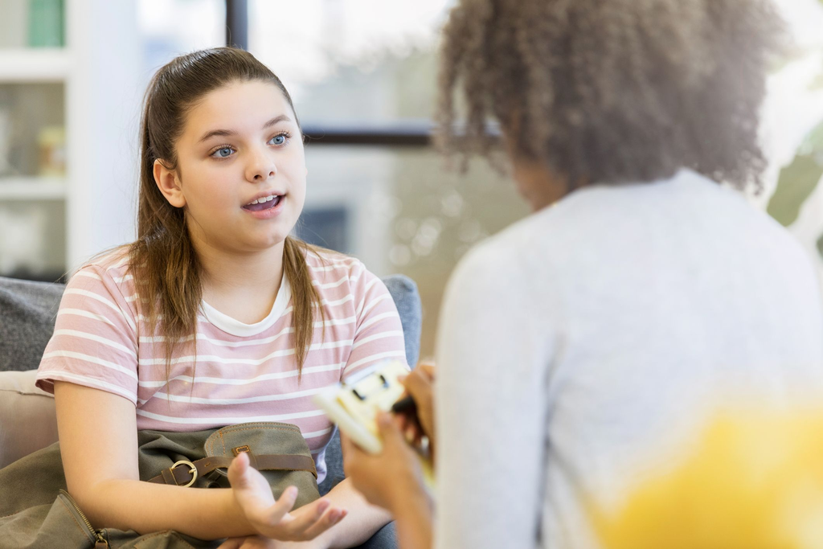

[Transforming mental health care for children and young people with long-term conditions: mental health and psychological wellbeing drop-in centre](https://www.nice.org.uk/sharedlearning/transforming-mental-health-care-for-children-and-young-people-with-long-term-conditions-mental-health-and-psychological-wellbeing-drop-in-centre)

People with long-term physical health problems are around 3 times more likely to have mental health problems than the general population. People with both physical and mental health problems face poorer clinical outcomes and a significantly lower quality of life than people with a physical health problem alone. This initiative aims to transform access to and delivery of mental health care in young people with physical health problems and will pave the way for future service developments. These will enable this population to have convenient access to high-quality, NICE-recommended, low-intensity psychological therapies that improve mental health and quality of life.

[SHAPE: Supporting Health And Promoting Exercise in young people with psychosis, University of Worcester](https://www.nice.org.uk/sharedlearning/shape-supporting-health-and-promoting-exercise-in-young-people-with-psychosis)

The SHAPE programme is a bespoke physical health monitoring and early intervention programme for young people with early psychosis. It is designed by young people with psychosis and a team of specialists. The programme aims to support young people experiencing a first episode psychosis to make lifestyle choices informed by an understanding of their greater risk for obesity, cardiovascular diseases and metabolic disorders. It also aims to provide access to healthcare in a positive and socially inclusive environment embracing the importance of ‘ordinary lives’.

### Other resources

[figure not shown]

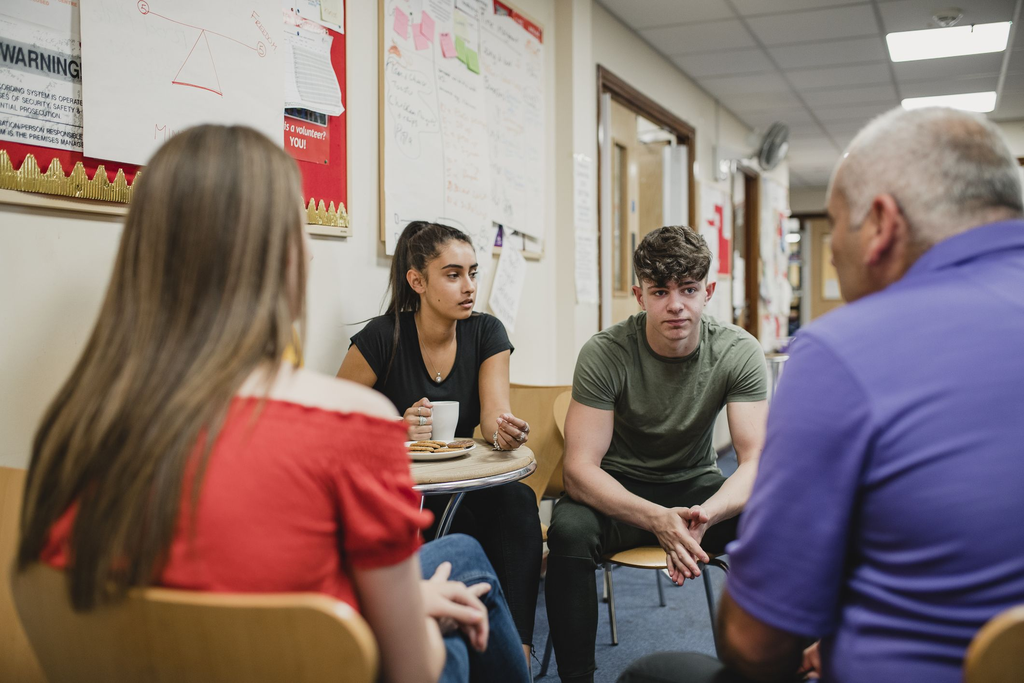

There are a number of other tools and resources that support the implementation of our guidance. Here, the [NICE guideline on psychosis and schizophrenia in children and young people](https://www.nice.org.uk/guidance/cg155) is used to demonstrate the types of other resources available to support implementation.

#### **Endorsed resources**

We have endorsed these tools produced by other organisations as supporting our guidance.

- The [competence framework](https://www.nice.org.uk/guidance/cg178/resources/endorsed-resource-competence-framework-for-psychological-interventions-for-people-with-psychosis-and-bipolar-disorder-2185285357) supports the recommendations relating to psychological interventions and sets out the things that CAMHS workers need to know about, or be able to do, so that they can do their job well.
- The Prescribing Observatory for mental health produced an [audit-based quality improvement programme](https://www.nice.org.uk/guidance/cg155/resources/the-prescribing-observatory-for-mental-health-topic-10-audit-report-2494521325) that supports the recommendations relating to monitoring physical health.
- [Positive Cardiometabolic Health Resource](https://www.nice.org.uk/guidance/cg155/resources/endorsed-resources-lester-uk-adaptation-positive-cardiometabolic-health-resource-556234093) is an intervention framework that supports the recommendations relating to monitoring physical health.

#### **Clinical audit tools**

These audit tools can be used as a starting point for local clinical audit projects to inform service improvement and improve the provision of psychological interventions for children and young people. Electronic tools are available to help you collect and analyse your data:

- [psychological interventions for first episode psychosis](https://www.nice.org.uk/guidance/cg155/resources)
- [assessment and care planning in secondary care](https://www.nice.org.uk/guidance/cg155/resources).

#### **Education support**

This resource supports the guideline recommendations in relation to detailing [treatment manuals for CBT for children and young people with psychosis or schizophrenia](https://www.nice.org.uk/guidance/cg155/resources/treatment-manuals-for-cbt-for-children-and-young-people-with-psychosis-or-schizophrenia-145409).

#### **NICEImpact: mental health report**

The [NICEimpact report on mental health](https://www.nice.org.uk/media/default/about/what-we-do/into-practice/measuring-uptake/niceimpact-mental-health.pdf) highlights progress made by the health and care system in implementing our guidance. It can be used to inform benchmarking and planning.

#### **Access and waiting time standard**

To help with implementation a number of waiting time standards have been published and are based on our guidance and quality standards.

- The [Implementing the early intervention in psychosis access and waiting time standard guidance](https://www.england.nhs.uk/mental-health/resources/access-waiting-time/) aims to drive the quality of care received by those with first episode psychosis, and greatly improve their ability to recover.
- [Access and Waiting Time Standard for Children and Young People with an Eating Disorder Commissioning Guide](https://www.england.nhs.uk/mental-health/cyp/eating-disorders/).

#### **NICE indicators**

We’ve developed a set of outcome indicators for bipolar, schizophrenia and other psychoses. Visit our [standards and indicators page](https://www.nice.org.uk/standards-and-indicators/index/QOF/Bipolar,%20schizophrenia%20and%20other%20psychoses) to see the care and treatment indicators and lifestyle indicators. Indicators can be particularly useful to local partnerships when:

- identifying where improvements are needed
- setting priorities for quality improvement and support
- creating local performance dashboards
- benchmarking performance against national data
- supporting local quality improvement schemes
- demonstrating progress that local health systems are making on outcomes.